# Mc Calla et al.

```python
from scdataloader import Preprocessor

from bengrn import BenGRN, get_sroy_gt, FILEDIR
import scanpy as sc

from anndata.utils import make_index_unique
from bengrn import compute_genie3, get_GT_db
from grnndata import utils as grnutils
import pandas as pd
import numpy as np

%load_ext autoreload
%autoreload 2

import torch
torch.set_float32_matmul_precision('medium')
```

from scdataloader import Preprocessor from bengrn import BenGRN, get_sroy_gt, FILEDIR import scanpy as sc from anndata.utils import make_index_unique from bengrn import compute_genie3, get_GT_db from grnndata import utils as grnutils import pandas as pd import numpy as np %load_ext autoreload %autoreload 2 import torch torch.set_float32_matmul_precision('medium')

```
/pasteur/appa/homes/jkalfon/miniconda3/envs/scprint17/lib/python3.10/site-packages/bitsandbytes/libbitsandbytes_cpu.so: undefined symbol: cadam32bit_grad_fp32
```

```
💡 connected lamindb: jkobject/scprint
```

```python
preprocessor = Preprocessor(is_symbol=True, force_preprocess=True, skip_validate=True,
                            do_postp=False, min_valid_genes_id=5000, min_dataset_size=64)
NUM_GENES = 5000
MAXCELLS = 1024
```

preprocessor = Preprocessor(is_symbol=True, force_preprocess=True, skip_validate=True, do_postp=False, min_valid_genes_id=5000, min_dataset_size=64) NUM_GENES = 5000 MAXCELLS = 1024

# han / full

```python
metrics = {}
```

metrics = {}

```python
preadata = get_sroy_gt(get="han", species="human", gt="full")
adata = preprocessor(preadata.copy())
adata.var["isTF"] = False
adata.var.loc[adata.var.symbol.isin(grnutils.TF), "isTF"] = True
preadata, (preadata.grn.sum(1) != 0).sum()
```

preadata = get_sroy_gt(get="han", species="human", gt="full") adata = preprocessor(preadata.copy()) adata.var["isTF"] = False adata.var.loc[adata.var.symbol.isin(grnutils.TF), "isTF"] = True preadata, (preadata.grn.sum(1) != 0).sum()

```
Dropping layers:  KeysView(Layers with keys: )
checking raw counts
```

```
removed 0 non primary cells, 5520 renamining
```

```
filtered out 0 cells, 5520 renamining
```

```
Removed 0 genes.
```

```
startin QC
```

```
Seeing 151 outliers (2.74% of total dataset):
done
```

```
(GRnnData object with n_obs × n_vars = 5520 × 7465
     obs: 'organism_ontology_term_id'
     varp: 'GRN'
     with a grn of 8463 elements,
 31)
```

```python
sc.pp.highly_variable_genes(
    adata, flavor="seurat_v3", n_top_genes=NUM_GENES)
adata.var['ensembl_id'] = adata.var.index
subadata = adata[:MAXCELLS, adata.var.highly_variable]

genie_grn = compute_genie3(subadata, nthreads=20)
genie_grn.var['symbol'] = make_index_unique(
    genie_grn.var['symbol'].astype(str))
genie_grn.var.index = genie_grn.var['symbol']
```

sc.pp.highly_variable_genes( adata, flavor="seurat_v3", n_top_genes=NUM_GENES) adata.var['ensembl_id'] = adata.var.index subadata = adata[:MAXCELLS, adata.var.highly_variable] genie_grn = compute_genie3(subadata, nthreads=20) genie_grn.var['symbol'] = make_index_unique( genie_grn.var['symbol'].astype(str)) genie_grn.var.index = genie_grn.var['symbol']

```
Tree method: RF
K: sqrt
Number of trees: 100


running jobs on 20 threads
```

```
Elapsed time: 734.93 seconds
```

```python
genie_grn.varp["GRN"] = genie_grn.varp["GRN"].T
metrics['genie3_han'] = BenGRN(genie_grn, do_auc=True, doplot=True).compare_to(other=preadata)
```

genie_grn.varp["GRN"] = genie_grn.varp["GRN"].T metrics['genie3_han'] = BenGRN(genie_grn, do_auc=True, doplot=True).compare_to(other=preadata)

```
precision:  0.029342280960043824
recall:  0.8544366899302094
random precision: 0.027392895508257013
```

```
Area Under Precision-Recall Curve (AUPRC):  0.02915976390645599
EPR: 1.4406568461077904
```

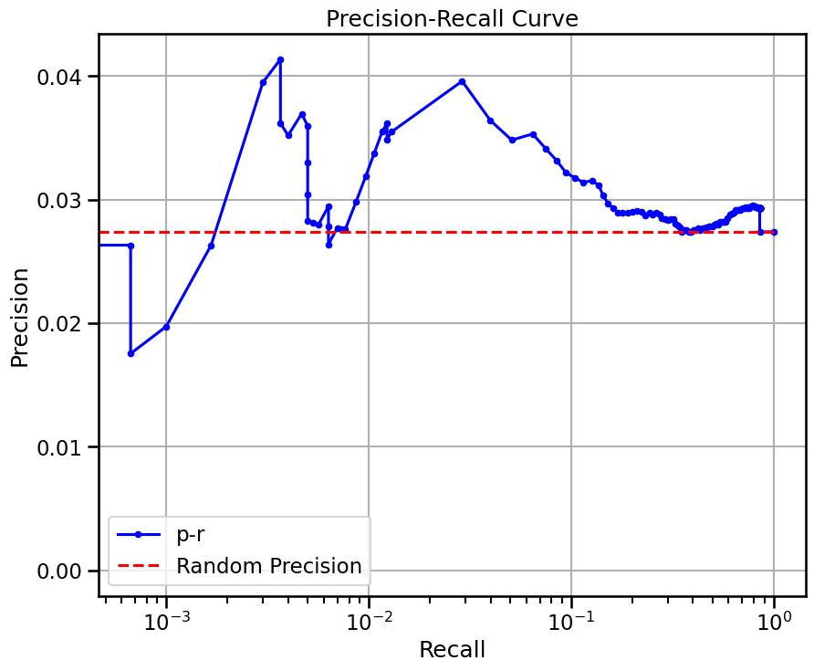

```python
genie_grn.varp["GRN"] = genie_grn.varp["GRN"].T
metrics['genie3_han_base'] = BenGRN(genie_grn, do_auc=True, doplot=True).scprint_benchmark()
```

genie_grn.varp["GRN"] = genie_grn.varp["GRN"].T metrics['genie3_han_base'] = BenGRN(genie_grn, do_auc=True, doplot=True).scprint_benchmark()

```
base enrichment
```

```
Top central genes: []
```

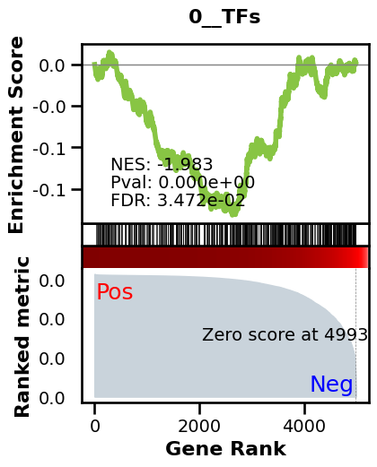

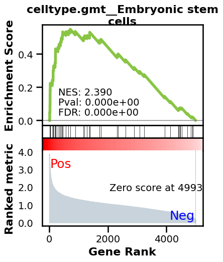

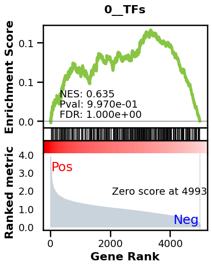

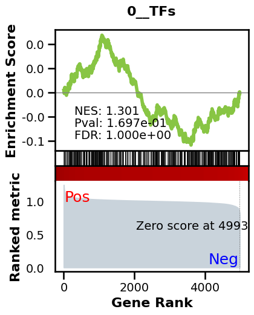

```
_________________________________________
TF specific enrichment
```

```
found some significant results for  11.320754716981131 % TFs

_________________________________________
loading GT,  omnipath
```

```
intersection of 3761 genes
intersection pct: 0.7531037244693632
precision:  0.0015467340286693517
recall:  0.7476461265964389
random precision: 0.0015171100940786458
```

```
Area Under Precision-Recall Curve (AUPRC):  0.0016742583517634193
```

```
EPR: 1.5077820027008297
```

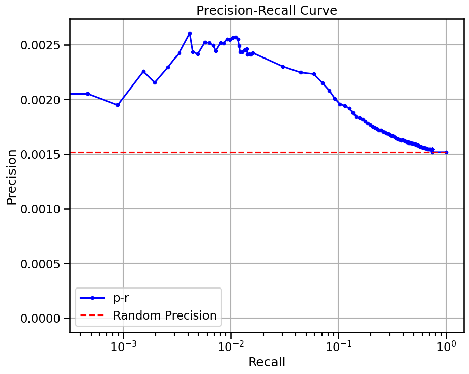

```python
preadata = get_sroy_gt(get="han", species="human", gt="chip")
genie_grn.varp["GRN"] = genie_grn.varp["GRN"].T
metrics['genie3_han_chip'] = BenGRN(genie_grn, do_auc=True, doplot=True).compare_to(other=preadata)
```

preadata = get_sroy_gt(get="han", species="human", gt="chip") genie_grn.varp["GRN"] = genie_grn.varp["GRN"].T metrics['genie3_han_chip'] = BenGRN(genie_grn, do_auc=True, doplot=True).compare_to(other=preadata)

```
precision:  0.2730288544606347
recall:  0.9129003061872942
random precision: 0.25366732938308756
```

```
Area Under Precision-Recall Curve (AUPRC):  0.27664613039034436
EPR: 1.2136454863964605
```

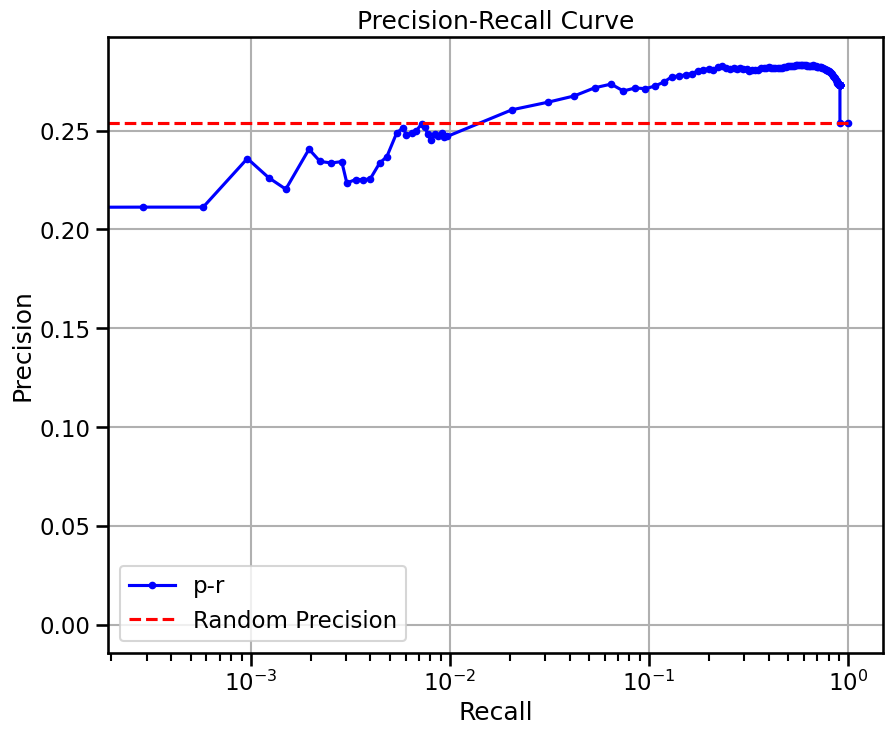

```python
preadata = get_sroy_gt(get="han", species="human", gt="ko")
metrics['genie3_tf_han_ko'] = BenGRN(genie_grn, do_auc=True, doplot=True).compare_to(other=preadata)
```

preadata = get_sroy_gt(get="han", species="human", gt="ko") metrics['genie3_tf_han_ko'] = BenGRN(genie_grn, do_auc=True, doplot=True).compare_to(other=preadata)

```
precision:  0.06953395104411561
recall:  0.6456990753712525
random precision: 0.07658579153672285
```

```
Area Under Precision-Recall Curve (AUPRC):  0.07062295330069966
EPR: 0.9949920973929479
```

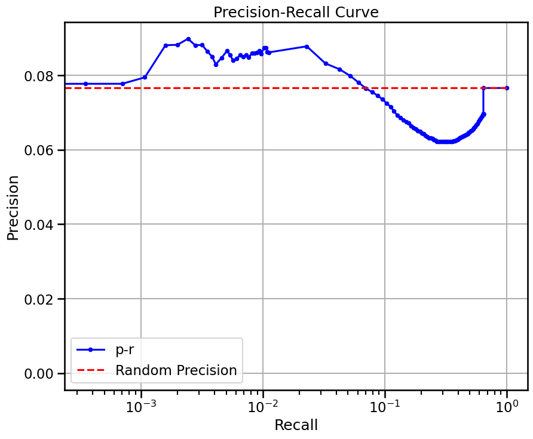

```python
sc.pp.highly_variable_genes(
    adata, flavor="seurat_v3", n_top_genes=NUM_GENES)
adata.var['ensembl_id'] = adata.var.index
subadata = adata[:MAXCELLS, adata.var.highly_variable]

genie_grn = compute_genie3(subadata, nthreads=20, regulators=adata.var[adata.var.isTF].index.tolist())
genie_grn.var['symbol'] = make_index_unique(
    genie_grn.var['symbol'].astype(str))
genie_grn.var.index = genie_grn.var['symbol']
genie_grn.varp["GRN"] = genie_grn.varp["GRN"].T
metrics['genie3_tf_han'] = BenGRN(genie_grn, do_auc=True, doplot=True).compare_to(other=preadata)
```

sc.pp.highly_variable_genes( adata, flavor="seurat_v3", n_top_genes=NUM_GENES) adata.var['ensembl_id'] = adata.var.index subadata = adata[:MAXCELLS, adata.var.highly_variable] genie_grn = compute_genie3(subadata, nthreads=20, regulators=adata.var[adata.var.isTF].index.tolist()) genie_grn.var['symbol'] = make_index_unique( genie_grn.var['symbol'].astype(str)) genie_grn.var.index = genie_grn.var['symbol'] genie_grn.varp["GRN"] = genie_grn.varp["GRN"].T metrics['genie3_tf_han'] = BenGRN(genie_grn, do_auc=True, doplot=True).compare_to(other=preadata)

```
Tree method: RF
K: sqrt
Number of trees: 100


running jobs on 20 threads
```

```
Elapsed time: 157.16 seconds
```

```
precision:  0.08761967165374394
recall:  0.1124031007751938
random precision: 0.07658579153672285
```

```
Area Under Precision-Recall Curve (AUPRC):  0.07749128445450512
EPR: 1.1181298298886302
```

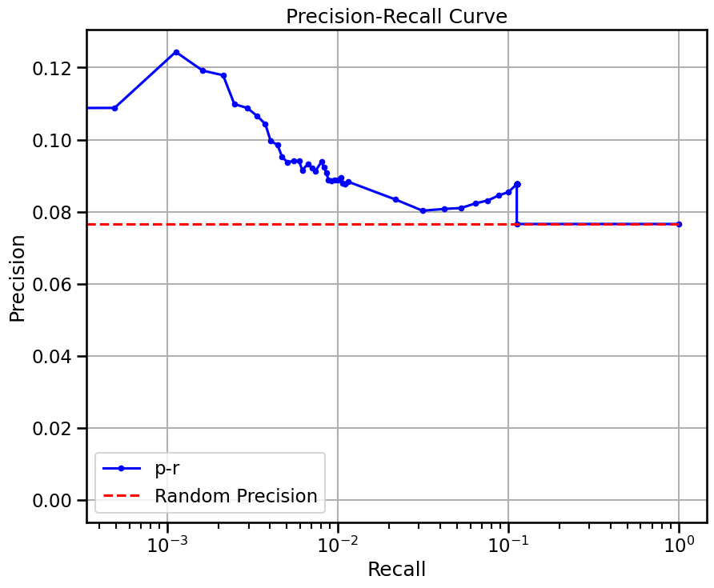

```python
genie_grn.varp["GRN"] = genie_grn.varp["GRN"].T
metrics['genie3_tf_han_base'] = BenGRN(genie_grn, do_auc=True, doplot=True).scprint_benchmark()
```

genie_grn.varp["GRN"] = genie_grn.varp["GRN"].T metrics['genie3_tf_han_base'] = BenGRN(genie_grn, do_auc=True, doplot=True).scprint_benchmark()

```
base enrichment
```

```
Top central genes: []
```

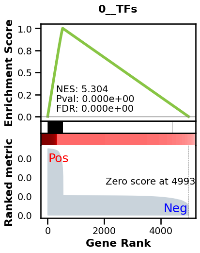

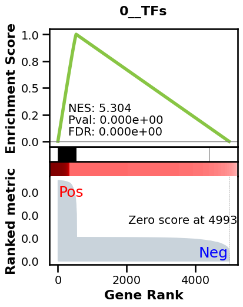

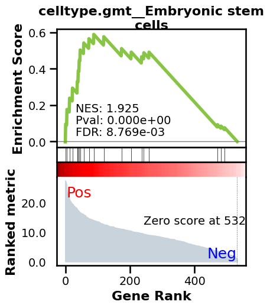

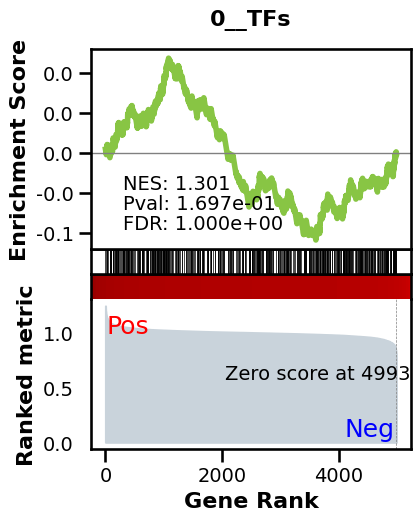

```
_________________________________________
TF specific enrichment
```

```
found some significant results for  15.09433962264151 % TFs

_________________________________________
loading GT,  omnipath
```

```
intersection of 3761 genes
intersection pct: 0.7531037244693632
precision:  0.006307904938243491
recall:  0.5035424629439732
random precision: 0.0015171100940786458
```

```
Area Under Precision-Recall Curve (AUPRC):  0.004684918809324256
EPR: 9.031160238233886
```

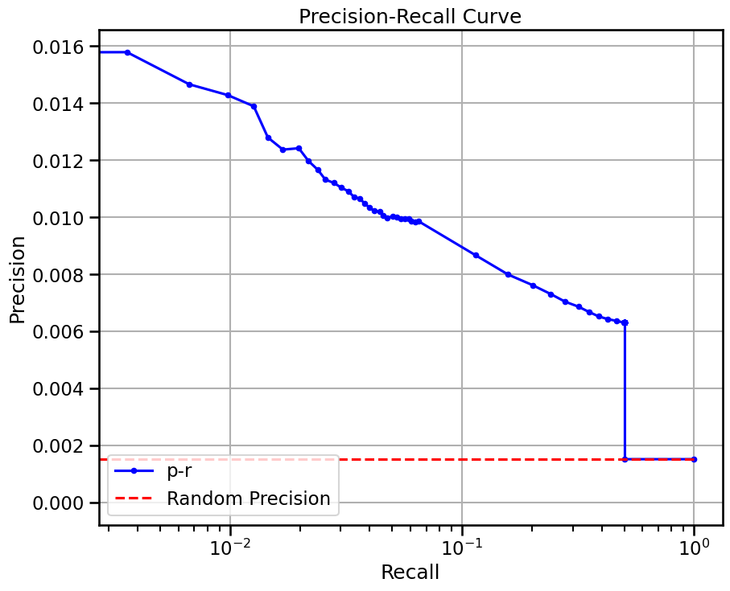

```python
genie_grn.varp["GRN"] = genie_grn.varp["GRN"].T
preadata = get_sroy_gt(get="han", species="human", gt="chip")
metrics['genie3_tf_han_chip'] = BenGRN(genie_grn, do_auc=True, doplot=True).compare_to(other=preadata)
```

genie_grn.varp["GRN"] = genie_grn.varp["GRN"].T preadata = get_sroy_gt(get="han", species="human", gt="chip") metrics['genie3_tf_han_chip'] = BenGRN(genie_grn, do_auc=True, doplot=True).compare_to(other=preadata)

```
precision:  0.3110521578473637
recall:  0.1264418725567602
random precision: 0.25366732938308756
```

```
Area Under Precision-Recall Curve (AUPRC):  0.2621239923166735
EPR: 0.7807812778526351
```

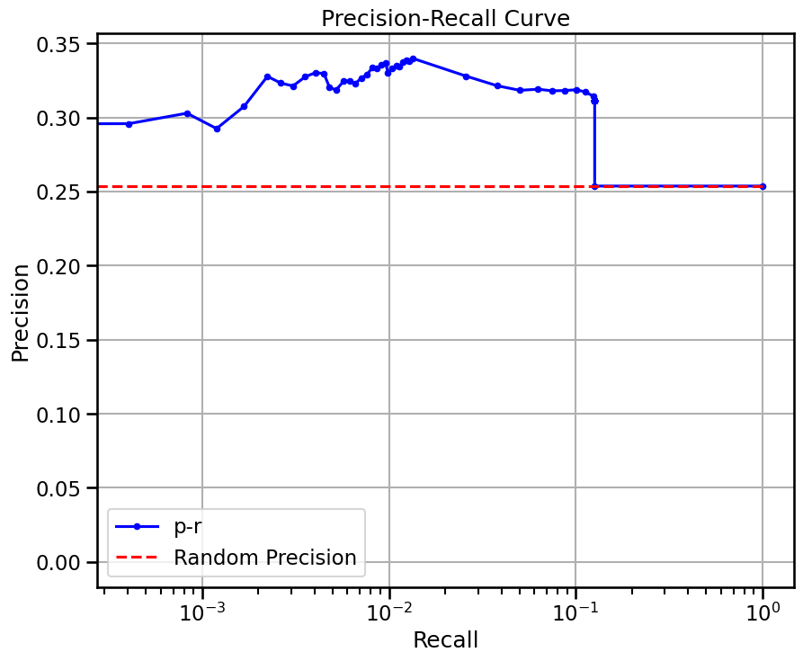

```python
preadata = get_sroy_gt(get="han", species="human", gt="ko")
metrics['genie3_tf_han_ko'] = BenGRN(genie_grn, do_auc=True, doplot=True).compare_to(other=preadata)
```

preadata = get_sroy_gt(get="han", species="human", gt="ko") metrics['genie3_tf_han_ko'] = BenGRN(genie_grn, do_auc=True, doplot=True).compare_to(other=preadata)

```
precision:  0.08761967165374394
recall:  0.1124031007751938
random precision: 0.07658579153672285
```

```
Area Under Precision-Recall Curve (AUPRC):  0.07749128445450512
EPR: 1.1181298298886302
```

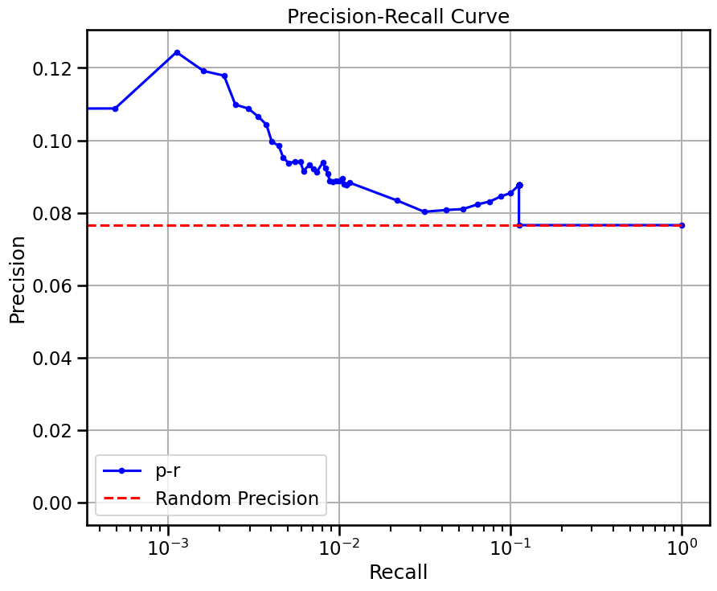

## trial with my own ESC

```python
preadata = get_sroy_gt(get="mine", species="human", gt="full")
adata = preprocessor(preadata.copy())
adata.var["isTF"] = False
adata.var.loc[adata.var.symbol.isin(grnutils.TF), "isTF"] = True
preadata, (preadata.grn.sum(1) != 0).sum()
```

preadata = get_sroy_gt(get="mine", species="human", gt="full") adata = preprocessor(preadata.copy()) adata.var["isTF"] = False adata.var.loc[adata.var.symbol.isin(grnutils.TF), "isTF"] = True preadata, (preadata.grn.sum(1) != 0).sum()

```
Dropping layers:  KeysView(Layers with keys: )
checking raw counts
Data is not raw counts, please check layers, find raw data, or bypass with force_preprocess
removed 0 non primary cells, 115 renamining
```

```
filtered out 0 cells, 115 renamining
Removed 0 genes.
```

```
startin QC
Seeing 104 outliers (90.43% of total dataset):
```

```
done
```

```
(GRnnData object with n_obs × n_vars = 115 × 28466
     obs: 'organism_ontology_term_id'
     var: 'ensembl_id'
     varp: 'GRN'
     with a grn of 11563 elements,
 35)
```

```python
sc.pp.highly_variable_genes(
    adata, flavor="seurat_v3", n_top_genes=NUM_GENES)
adata.var['ensembl_id'] = adata.var.index
subadata = adata[:MAXCELLS, adata.var.highly_variable]
genie_grn = compute_genie3(subadata, nthreads=20,
                            regulators=adata.var[adata.var.isTF].index.tolist())
genie_grn.var.index = genie_grn.var['symbol']
genie_grn.varp["GRN"] = genie_grn.varp["GRN"].T
metrics['genie3_tf_mine'] = BenGRN(genie_grn, do_auc=True, doplot=True).compare_to(other=preadata)
```

sc.pp.highly_variable_genes( adata, flavor="seurat_v3", n_top_genes=NUM_GENES) adata.var['ensembl_id'] = adata.var.index subadata = adata[:MAXCELLS, adata.var.highly_variable] genie_grn = compute_genie3(subadata, nthreads=20, regulators=adata.var[adata.var.isTF].index.tolist()) genie_grn.var.index = genie_grn.var['symbol'] genie_grn.varp["GRN"] = genie_grn.varp["GRN"].T metrics['genie3_tf_mine'] = BenGRN(genie_grn, do_auc=True, doplot=True).compare_to(other=preadata)

```
Tree method: RF
K: sqrt
Number of trees: 100


running jobs on 20 threads
```

```
Elapsed time: 32.97 seconds
```

```
precision:  0.03948045267489712
recall:  0.1608171817705605
random precision: 0.024704298988016668
```

```
Area Under Precision-Recall Curve (AUPRC):  0.028198390149234705
EPR: 2.1729800471714205
```

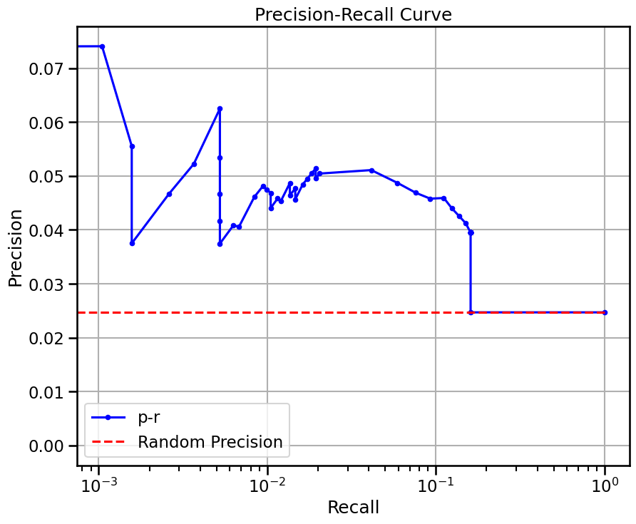

```python
genie_grn.varp["GRN"] = genie_grn.varp["GRN"].T
metrics['genie3_tf_mine_base'] = BenGRN(genie_grn, do_auc=True, doplot=True).scprint_benchmark()
```

genie_grn.varp["GRN"] = genie_grn.varp["GRN"].T metrics['genie3_tf_mine_base'] = BenGRN(genie_grn, do_auc=True, doplot=True).scprint_benchmark()

```
base enrichment
```

```
Top central genes: []
```

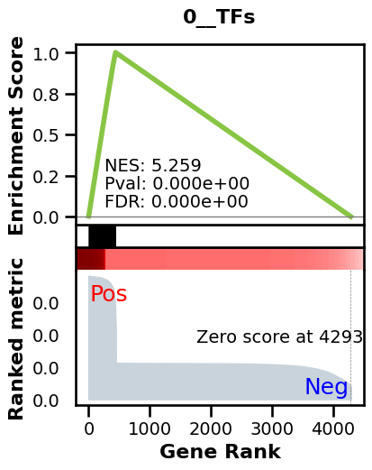

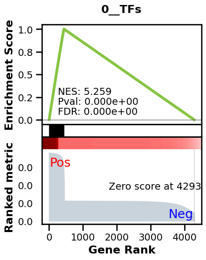

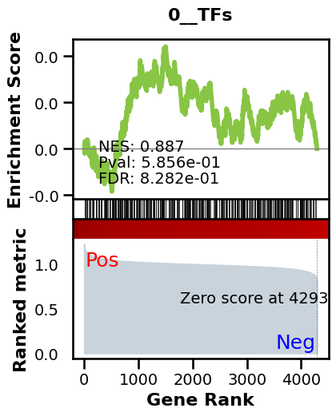

```
_________________________________________
TF specific enrichment
```

```
found some significant results for  0.0 % TFs

_________________________________________
loading GT,  omnipath
```

```
intersection of 2827 genes
intersection pct: 0.6583605030274802
precision:  0.008025132541106159
recall:  0.6641403740011533
random precision: 0.0015194448637656647
```

```
Area Under Precision-Recall Curve (AUPRC):  0.0068633395878915085
EPR: 8.88103865934905
```

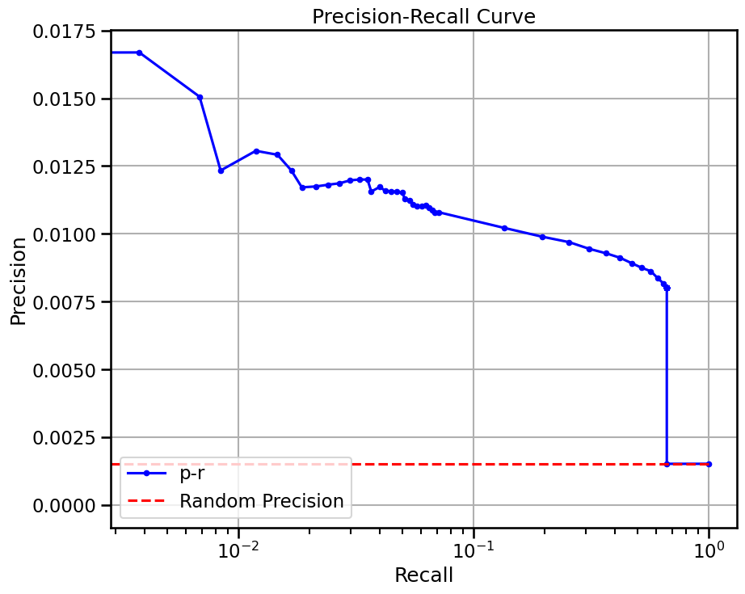

```python
sc.pp.highly_variable_genes(
    adata, flavor="seurat_v3", n_top_genes=NUM_GENES)
adata.var['ensembl_id'] = adata.var.index
subadata = adata[:MAXCELLS, adata.var.highly_variable]
genie_grn = compute_genie3(subadata, nthreads=20)
genie_grn.var['symbol'] = make_index_unique(
    genie_grn.var['symbol'].astype(str))
genie_grn.var.index = genie_grn.var['symbol']
genie_grn.varp["GRN"] = genie_grn.varp["GRN"].T
metrics['genie3_mine'] = BenGRN(genie_grn, do_auc=True, doplot=True).compare_to(other=preadata)
```

sc.pp.highly_variable_genes( adata, flavor="seurat_v3", n_top_genes=NUM_GENES) adata.var['ensembl_id'] = adata.var.index subadata = adata[:MAXCELLS, adata.var.highly_variable] genie_grn = compute_genie3(subadata, nthreads=20) genie_grn.var['symbol'] = make_index_unique( genie_grn.var['symbol'].astype(str)) genie_grn.var.index = genie_grn.var['symbol'] genie_grn.varp["GRN"] = genie_grn.varp["GRN"].T metrics['genie3_mine'] = BenGRN(genie_grn, do_auc=True, doplot=True).compare_to(other=preadata)

```
Tree method: RF
K: sqrt
Number of trees: 100


running jobs on 20 threads
```

```
Elapsed time: 63.27 seconds
```

```
precision:  0.0279467834834104
recall:  0.7218438973284442
random precision: 0.024704298988016668
```

```
Area Under Precision-Recall Curve (AUPRC):  0.02860060365652824
EPR: 1.0859440629124224
```

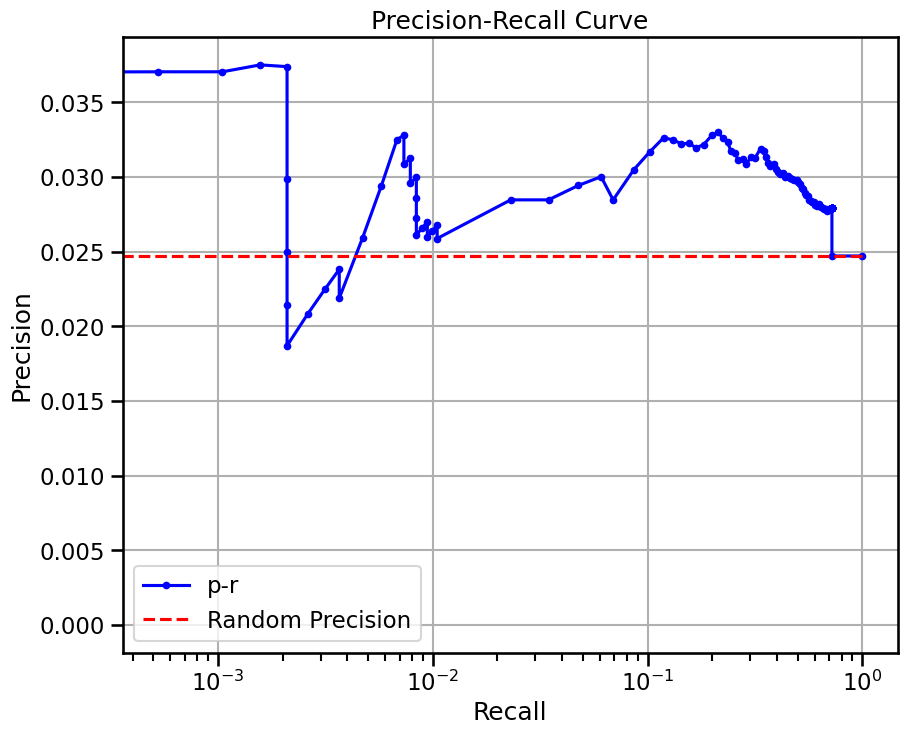

```python
genie_grn.varp["GRN"] = genie_grn.varp["GRN"].T
metrics['genie3_mine_base'] = BenGRN(genie_grn, do_auc=True, doplot=True).scprint_benchmark()
```

genie_grn.varp["GRN"] = genie_grn.varp["GRN"].T metrics['genie3_mine_base'] = BenGRN(genie_grn, do_auc=True, doplot=True).scprint_benchmark()

```
base enrichment
```

```
Top central genes: []
```

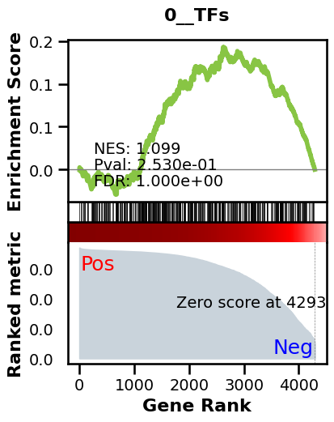

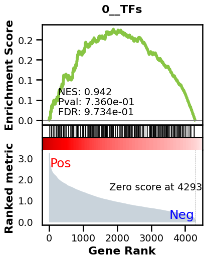

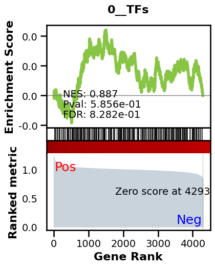

```
_________________________________________
TF specific enrichment
```

```
found some significant results for  0.0 % TFs

_________________________________________
loading GT,  omnipath
```

```
intersection of 2827 genes
intersection pct: 0.6583605030274802
precision:  0.0017314456700680625
recall:  0.6061454815058901
random precision: 0.0015194448637656647
```

```
Area Under Precision-Recall Curve (AUPRC):  0.0017161503485220364
EPR: 1.738820781076889
```

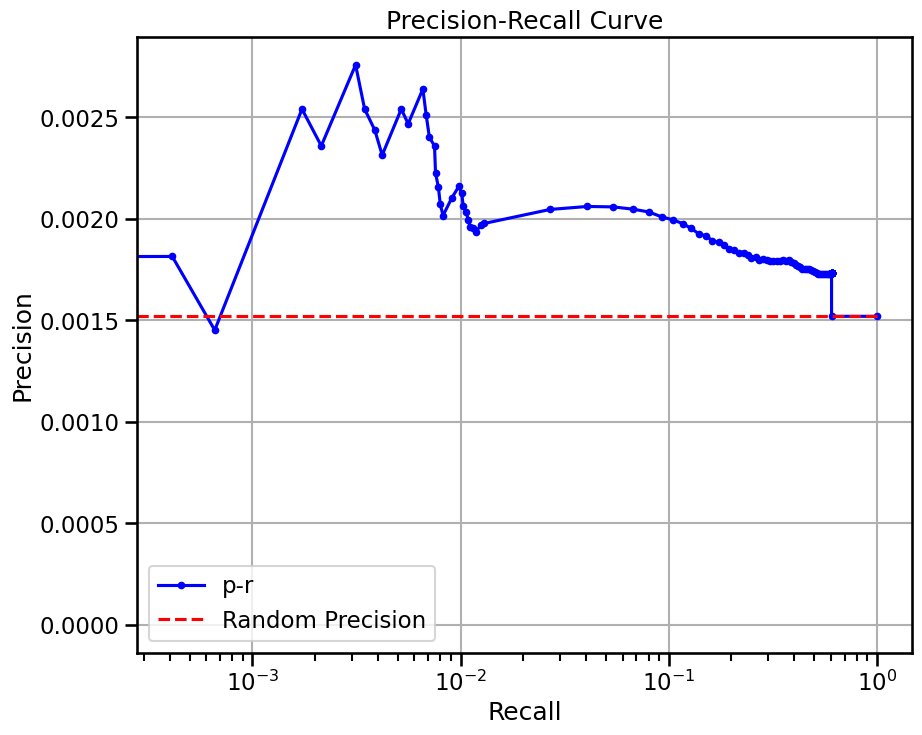

## trial with the other two mouse dataset

```python
preadata = get_sroy_gt(get="tran", species="mouse", gt="full")
adata = preprocessor(preadata.copy())
adata.var["isTF"] = False
adata.var.loc[adata.var.symbol.isin(grnutils.mTF), "isTF"] = True
preadata, (preadata.grn.sum(1) != 0).sum()
```

preadata = get_sroy_gt(get="tran", species="mouse", gt="full") adata = preprocessor(preadata.copy()) adata.var["isTF"] = False adata.var.loc[adata.var.symbol.isin(grnutils.mTF), "isTF"] = True preadata, (preadata.grn.sum(1) != 0).sum()

```
Dropping layers:  KeysView(Layers with keys: )
checking raw counts
removed 0 non primary cells, 2369 renamining
```

```
filtered out 0 cells, 2369 renamining
Removed 0 genes.
```

```
startin QC
Seeing 91 outliers (3.84% of total dataset):
done
```

```
(GRnnData object with n_obs × n_vars = 2369 × 6618
     obs: 'organism_ontology_term_id'
     varp: 'GRN'
     with a grn of 7162 elements,
 31)
```

```python
sc.pp.highly_variable_genes(
    adata, flavor="seurat_v3", n_top_genes=NUM_GENES)
adata.var['ensembl_id'] = adata.var.index
subadata = adata[:MAXCELLS, adata.var.highly_variable]
genie_grn = compute_genie3(subadata, nthreads=32,
                            regulators=adata.var[adata.var.isTF].index.tolist())
genie_grn.var['symbol'] = make_index_unique(
    genie_grn.var['symbol'].astype(str))
genie_grn.var.index = genie_grn.var['symbol']
genie_grn.varp["GRN"] = genie_grn.varp["GRN"].T
metrics['genie3_tf_tran'] = BenGRN(genie_grn, do_auc=True, doplot=True).compare_to(other=preadata)
```

sc.pp.highly_variable_genes( adata, flavor="seurat_v3", n_top_genes=NUM_GENES) adata.var['ensembl_id'] = adata.var.index subadata = adata[:MAXCELLS, adata.var.highly_variable] genie_grn = compute_genie3(subadata, nthreads=32, regulators=adata.var[adata.var.isTF].index.tolist()) genie_grn.var['symbol'] = make_index_unique( genie_grn.var['symbol'].astype(str)) genie_grn.var.index = genie_grn.var['symbol'] genie_grn.varp["GRN"] = genie_grn.varp["GRN"].T metrics['genie3_tf_tran'] = BenGRN(genie_grn, do_auc=True, doplot=True).compare_to(other=preadata)

```
Tree method: RF
K: sqrt
Number of trees: 100


running jobs on 32 threads
```

```
Elapsed time: 75.88 seconds
```

```
precision:  0.04226938068427891
recall:  0.09752198241406874
random precision: 0.04047724974721941
```

```
Area Under Precision-Recall Curve (AUPRC):  0.042368632892678136
EPR: 1.2206217101854266
```

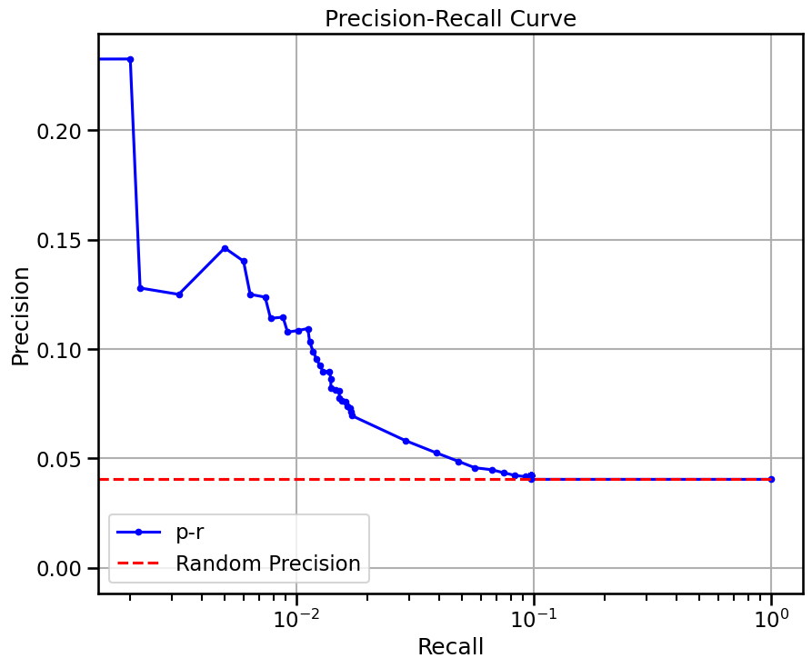

```python
preadata = get_sroy_gt(get="tran", species="mouse", gt="chip")
genie_grn.varp["GRN"] = genie_grn.varp["GRN"].T
metrics['genie3_tf_tran_chip'] = BenGRN(genie_grn, do_auc=True, doplot=True).compare_to(other=preadata)
```

preadata = get_sroy_gt(get="tran", species="mouse", gt="chip") genie_grn.varp["GRN"] = genie_grn.varp["GRN"].T metrics['genie3_tf_tran_chip'] = BenGRN(genie_grn, do_auc=True, doplot=True).compare_to(other=preadata)

```
precision:  0.21807607090103398
recall:  0.7748983073087521
random precision: 0.1988584102547376
```

```
Area Under Precision-Recall Curve (AUPRC):  0.2291119909587641
EPR: 1.4766262048123415
```

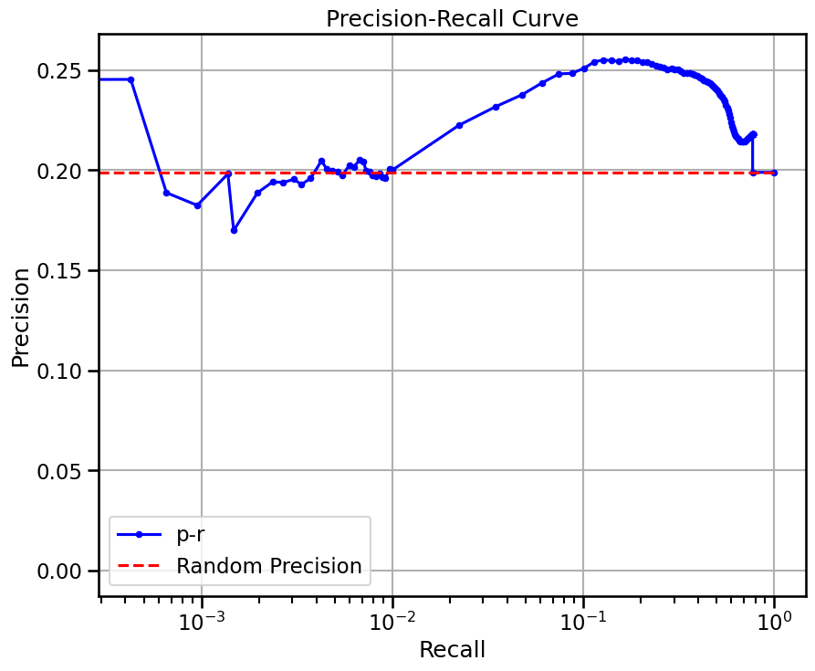

```python
preadata = get_sroy_gt(get="tran", species="mouse", gt="ko")
metrics['genie3_tf_tran_ko'] = BenGRN(genie_grn, do_auc=True, doplot=True).compare_to(other=preadata)
```

preadata = get_sroy_gt(get="tran", species="mouse", gt="ko") metrics['genie3_tf_tran_ko'] = BenGRN(genie_grn, do_auc=True, doplot=True).compare_to(other=preadata)

```
precision:  0.09365313962255119
recall:  0.764830922595778
random precision: 0.07958310647896087
```

```
Area Under Precision-Recall Curve (AUPRC):  0.08242784708380184
EPR: 0.9768210945869907
```

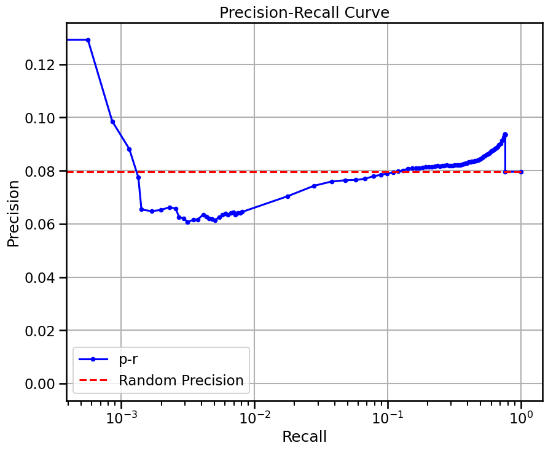

```python
sc.pp.highly_variable_genes(
    adata, flavor="seurat_v3", n_top_genes=NUM_GENES)
adata.var['ensembl_id'] = adata.var.index
subadata = adata[:MAXCELLS, adata.var.highly_variable]
genie_grn = compute_genie3(subadata, nthreads=20)
genie_grn.var['symbol'] = make_index_unique(
    genie_grn.var['symbol'].astype(str))
genie_grn.var.index = genie_grn.var['symbol']
genie_grn.varp["GRN"] = genie_grn.varp["GRN"].T
metrics['genie3_tran'] = BenGRN(genie_grn, do_auc=True, doplot=True).compare_to(other=preadata)
```

sc.pp.highly_variable_genes( adata, flavor="seurat_v3", n_top_genes=NUM_GENES) adata.var['ensembl_id'] = adata.var.index subadata = adata[:MAXCELLS, adata.var.highly_variable] genie_grn = compute_genie3(subadata, nthreads=20) genie_grn.var['symbol'] = make_index_unique( genie_grn.var['symbol'].astype(str)) genie_grn.var.index = genie_grn.var['symbol'] genie_grn.varp["GRN"] = genie_grn.varp["GRN"].T metrics['genie3_tran'] = BenGRN(genie_grn, do_auc=True, doplot=True).compare_to(other=preadata)

```
Tree method: RF
K: sqrt
Number of trees: 100


running jobs on 20 threads
```

```
Elapsed time: 365.53 seconds
```

```
precision:  0.06508251488282132
recall:  0.5697566458170445
random precision: 0.07958310647896087
```

```
Area Under Precision-Recall Curve (AUPRC):  0.07366483425230348
EPR: 0.9743024438020789
```

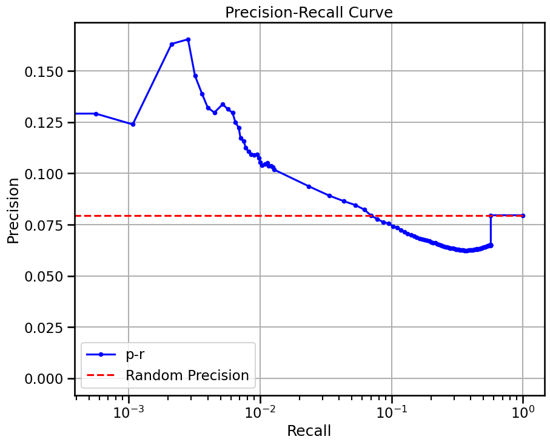

```python
preadata = get_sroy_gt(get="tran", species="mouse", gt="chip")
metrics['genie3_tran_chip'] = BenGRN(genie_grn, do_auc=True, doplot=True).compare_to(other=preadata)
```

preadata = get_sroy_gt(get="tran", species="mouse", gt="chip") metrics['genie3_tran_chip'] = BenGRN(genie_grn, do_auc=True, doplot=True).compare_to(other=preadata)

```
precision:  0.19429942296717465
recall:  0.6031032672877575
random precision: 0.1988584102547376
```

```
Area Under Precision-Recall Curve (AUPRC):  0.1972164610111044
EPR: 0.9496766892016936
```

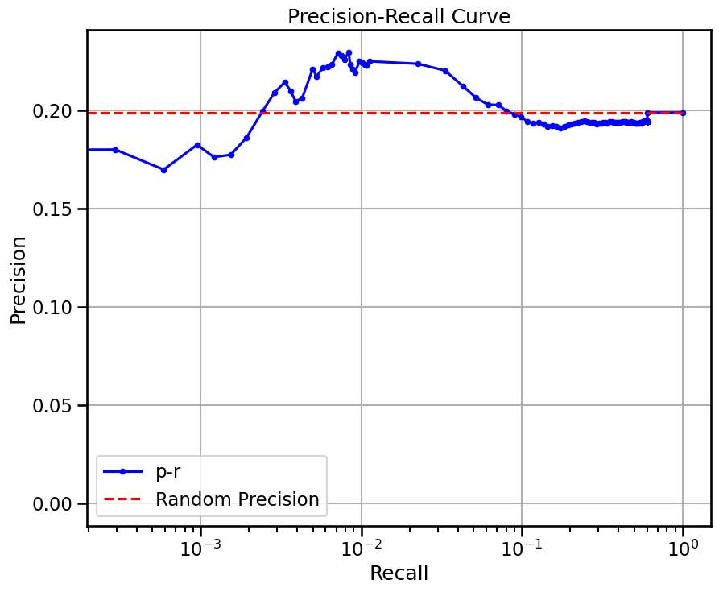

```python
preadata = get_sroy_gt(get="tran", species="mouse", gt="ko")
metrics['genie3_tran_ko'] = BenGRN(genie_grn, do_auc=True, doplot=True).compare_to(other=preadata)
```

preadata = get_sroy_gt(get="tran", species="mouse", gt="ko") metrics['genie3_tran_ko'] = BenGRN(genie_grn, do_auc=True, doplot=True).compare_to(other=preadata)

```
precision:  0.06508251488282132
recall:  0.5697566458170445
random precision: 0.07958310647896087
```

```
Area Under Precision-Recall Curve (AUPRC):  0.07366483425230348
EPR: 0.9743024438020789
```

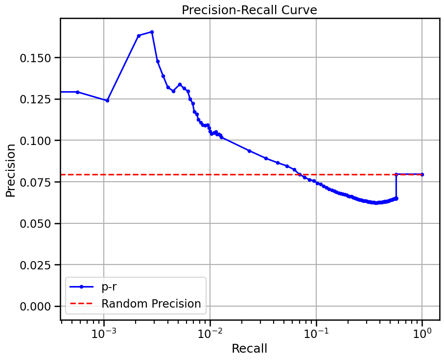